# ST558 - Project 1 - JSON Vignette

## Exploratory Data Analysis

An exploratory data analysis will be performed to check the single variable distributions and properties of the variables of interest in the data set in order to help validate the data and check for errors or other potentially interesting features of interest.

### Quantitative Variables

Numerical summaries and histograms for quantitative variables is provided below.

```r
# (i) getting numerical summaries of data
# (ia) price
summary(myData$price) %>%
  t() %>%
  as.data.frame() %>%
  mutate(Value=round(Freq,2)) %>%
  select(-Var1,-Freq) %>%
  rename("Price"=Var2) %>%
  kable()
```

| Price | Value |
| --- | --- |
| Min. | 0.00 |
| 1st Qu. | 5.99 |
| Median | 9.99 |
| Mean | 13.03 |
| 3rd Qu. | 17.35 |
| Max. | 69.49 |

```r
# (ib) player_rating
summary(myData$player_rating) %>%
  t() %>%
  as.data.frame() %>%
  mutate(Value=round(Freq,2)) %>%
  select(-Var1,-Freq) %>%
  rename("Player Rating"=Var2) %>%
  kable()
```

| Player Rating | Value |
| --- | --- |
| Min. | 2.30 |
| 1st Qu. | 3.80 |
| Median | 4.20 |
| Mean | 4.11 |
| 3rd Qu. | 4.50 |
| Max. | 4.90 |

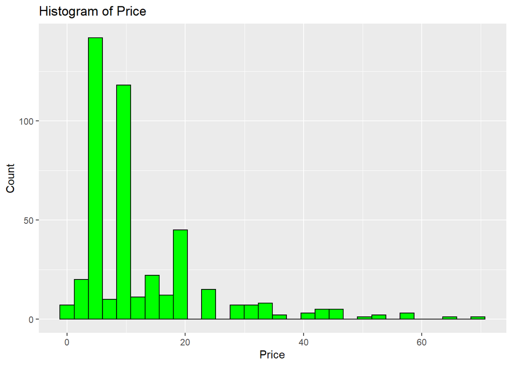

```r
# assessing single variable features, distributions
# (ii) exploratory analysis - variables treated as quantitative
# (iia) price
ggplot(myData, aes(x=price)) +
  geom_histogram(color="black", fill="green") +
  labs(title="Histogram of Price",
       x="Price",
       y="Count")
```

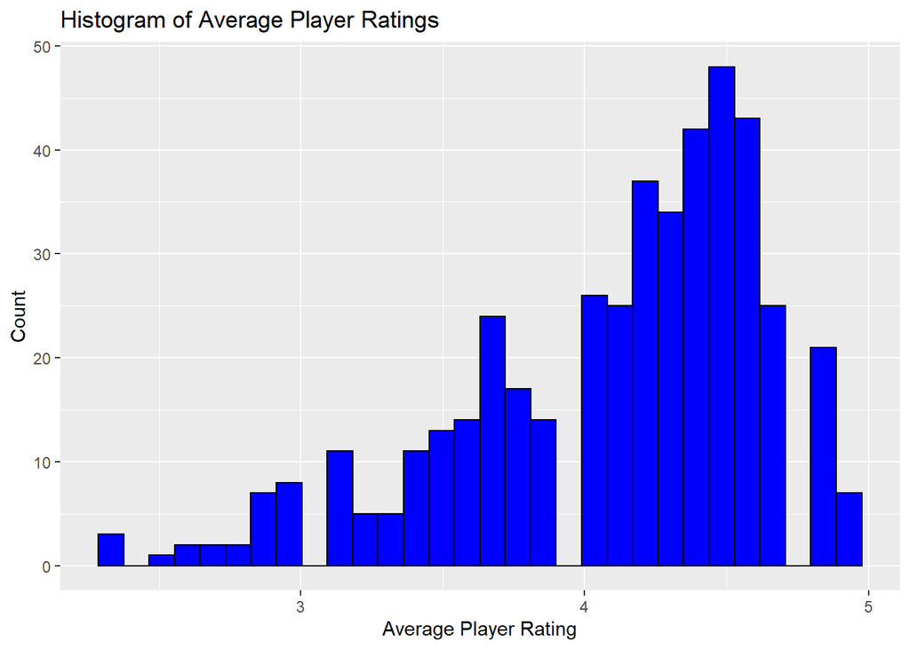

```r
# (iib) player_rating
ggplot(myData, aes(player_rating)) +
  geom_histogram(color="black", fill="blue") +
  labs(title="Histogram of Average Player Ratings",
       x="Average Player Rating",
       y="Count")
```

From these data we find that is a large variation in price and player rating. Player rating seems to be more of a skewed normal distribution than price data, which appears multi-modal. On inspection, both of these features appear to make sense. Pricing should have certain expected price points for games that likely occur more frequently than others, potentially explaining multi-modality. Player rating will also have floor and ceiling effects due to the limits in scale (1-5) within the rating, which likely explains the skewness in distribution.

### Categorical Variables

Single-variable tables and contingency tables will be used to asses the counts for each level of the categorical variables in the data.

```r
# (i) exploratory analysis - variables treated as categorical
# (ia) table, counts by genre
library(stringr)
genreNames <- str_remove(topGenres, "genre")
sapply(topGenres, function(Count) sum(myData[[Count]])) %>%
  as.data.frame() %>%
  mutate(Genre=genreNames) %>%
  rename(Count=".") %>%
  select(Genre, Count) %>%
  kable()
```

| Genre | Count |
| --- | --- |
| Action | 167 |
| Adventure | 148 |
| Strategy | 155 |
| Fantasy | 141 |
| Role-playing | 86 |

```r
# (ib) table, counts by publisher
table(myData$publisher) %>%
  as.data.frame() %>%
  rename(Publisher=Var1, Count=Freq) %>%
  arrange(desc(Count)) %>%
  kable()
```

| Publisher | Count |
| --- | --- |
| THQ Nordic GmbH | 57 |
| Activision | 51 |
| Ubisoft | 51 |
| Electronic Arts | 46 |
| Disney | 35 |
| Daedalic Entertainment | 32 |
| Devolver Digital | 32 |
| Interplay | 32 |
| 2K Games | 25 |
| Kalypso Media Digital | 24 |
| 1C Publishing | 21 |
| XSEED Games | 15 |
| Slitherine Ltd. | 11 |
| Versus Evil | 9 |
| Stardock Entertainment | 6 |

```r
# (ic) table, single-player and multi-player games
table(myData$single_player, myData$multi_player) %>%
  as.data.frame() %>%
  rename("Single-Player"=Var1, "Multi-Player"=Var2, "Count"=Freq) %>%
  kable()
```

| Single-Player | Multi-Player | Count |
| --- | --- | --- |
| TRUE | FALSE | 332 |
| TRUE | TRUE | 115 |

```r
# (ii) contingency table, genre x publisher
res <- sapply(topGenres, FUN=function(x){
         tapply(myData[[x]], myData$publisher, sum)
         }) %>%
       as.data.frame()
names(res) <- genreNames
kable(res)
```

|  | Action | Adventure | Strategy | Fantasy | Role-playing |
| --- | --- | --- | --- | --- | --- |
| 1C Publishing | 6 | 3 | 12 | 7 | 5 |
| 2K Games | 11 | 5 | 13 | 0 | 2 |
| Activision | 13 | 31 | 11 | 15 | 9 |
| Daedalic Entertainment | 5 | 24 | 7 | 9 | 2 |
| Devolver Digital | 23 | 13 | 1 | 6 | 1 |
| Disney | 18 | 18 | 4 | 6 | 2 |
| Electronic Arts | 26 | 12 | 9 | 22 | 16 |
| Interplay | 17 | 10 | 7 | 6 | 3 |
| Kalypso Media Digital | 3 | 0 | 21 | 5 | 3 |
| Slitherine Ltd. | 0 | 0 | 11 | 0 | 0 |
| Stardock Entertainment | 1 | 0 | 6 | 1 | 0 |
| THQ Nordic GmbH | 20 | 19 | 21 | 19 | 15 |
| Ubisoft | 17 | 7 | 26 | 25 | 9 |
| Versus Evil | 1 | 2 | 5 | 7 | 5 |
| XSEED Games | 6 | 4 | 1 | 13 | 14 |

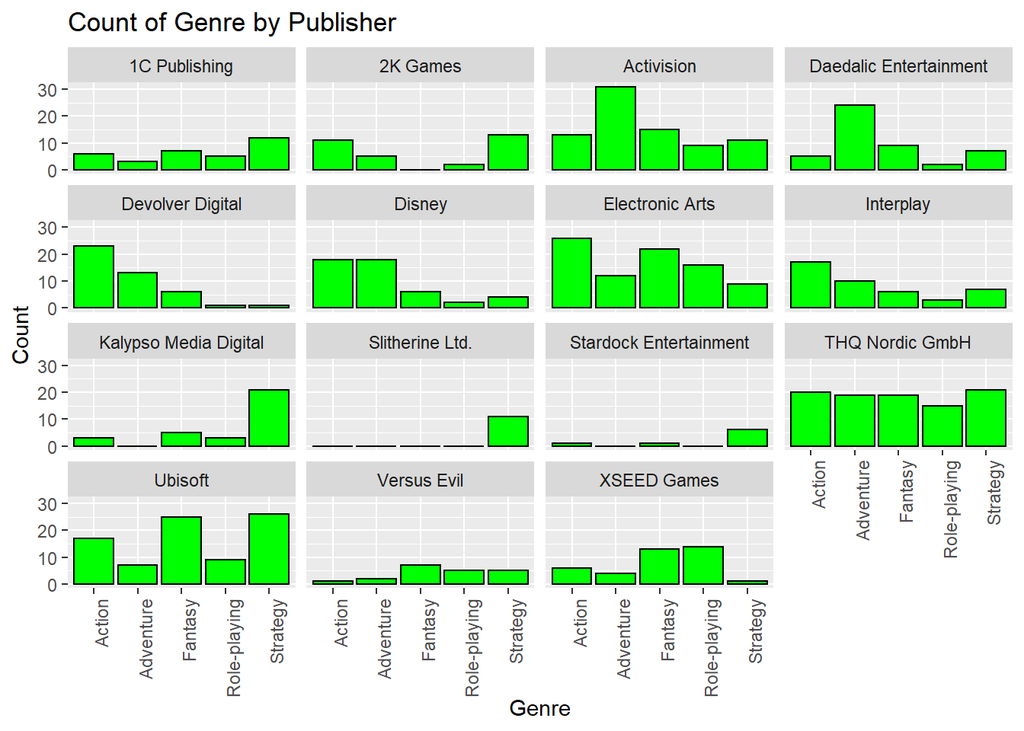

```r
# (iii) rework table of counts for plotting
res$Publisher <- rownames(res)
rownames(res) <- NULL
res           <- gather(res, names(res)[1]:names(res)[length(res)-1],
                        key="Genre",
                        value="Count")


# (iv) side-by-side bar plots - genre x publisher
ggplot(res, aes(x=Genre)) +
  geom_bar(aes(y=Count), color="black", fill="green", stat="identity") +
  facet_wrap(~Publisher) +
  theme(axis.text.x = element_text(angle = 90, hjust = 1)) +
  labs(title="Count of Genre by Publisher")
```

From these data we observe that top publishers tend to have reasonably diversified catelogs of game portfolios (appealing to multiple different genres), which makes sense given probable business needs. However, publishers appear to have specializations and differing distributions overall which suggests possible concern for confounding when attempting to relate player rating to either publisher or genre alone.

Another interesting observation is that the contingency table of single-player versus multi-player games revealed that the GOG.com catalog of games offers no games that are exclusively multi-player after applying our filters to the data. Therefore, it makes sense to only focus on the `multi_player` variable as a lone contrast, since all games in this set of data appear to at least have a single-player component. This analysis strategy will be reflected by modification to the factor as shown below:

```r
myData$multi_player <- factor(myData$multi_player,
                              levels=c(F, T),
                              labels=c("No MultiPlayer", "Has MultiPlayer"))
```

## Analysis: Interactions with Player Rating

Since I am primarily interested in player rating as a response variable, the following breakdowns were made by `player_rating` to examine what kinds of direct effects on player rating may exist in the data set. To get 2-way data for the genre variable (currently spread out across logical columns), I will create a custom function, which returns the relevant data frame. This essentially lengthens the data set using the genre logical columns by the indicated column(s) of data.

```r
# will lengthen data by colNames key only if TRUE using targetCol values
longFromLogicals <- function(data, colNames, targetCols, key="key"){
  # initialize empty data frame
  dfResult          <- data.frame()
  dfResult[[key]]   <- character()
  for(col in targetCols){
    dfResult[[col]] <- numeric()
  }

  # by row, by logical column,
  #   if true: get value from targetCol, lengthen dfResult
  #   else: pass
  for(i in 1:nrow(data)){
    for(j in colNames){
      if(data[[j]][i]){
        tempList          <- list()
        tempList[[key]]   <- j
        for(col in targetCols){
          tempList[[col]] <- data[[col]][i]
        }
        dfResult <- rbind.data.frame(dfResult, tempList, stringsAsFactors=F)
      }
    }
  }

  # return result
  dfResult
}
```

Next, I will plot several multivariate plots with player rating to investigate for the presence of potentially interesting relationships or observations worth further investigation.

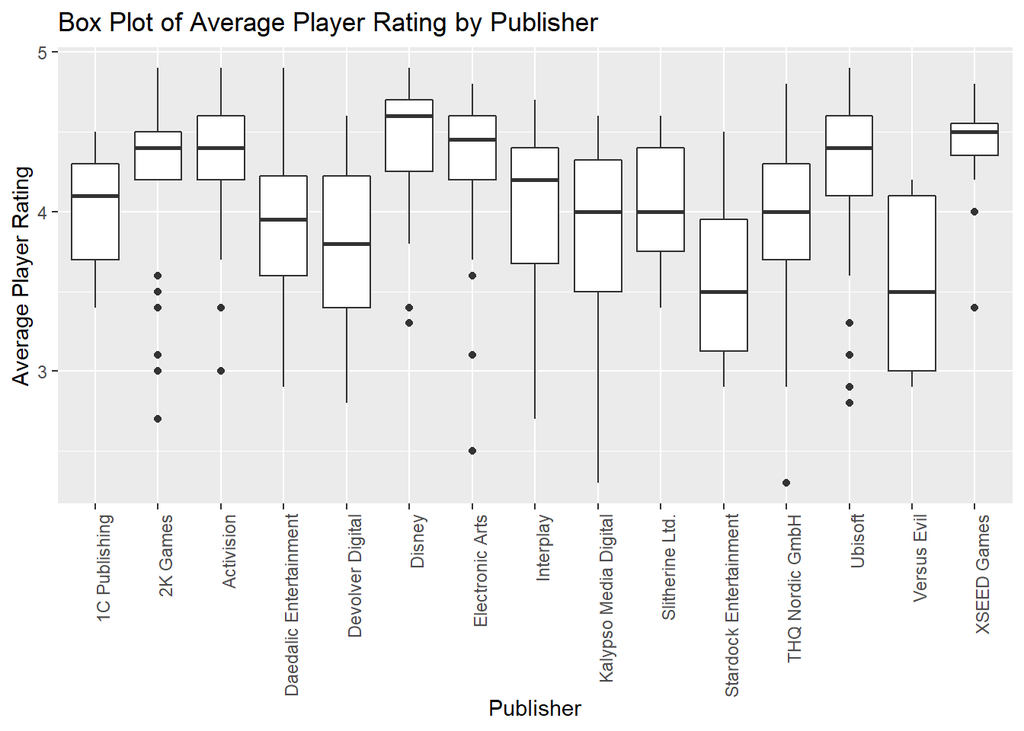

```r
# (ia) box_plots: player rating by publisher
ggplot(myData, aes(x=publisher, y=player_rating)) +
  geom_boxplot() +
  labs(title="Box Plot of Average Player Rating by Publisher",
       x = "Publisher",
       y = "Average Player Rating") +
   theme(axis.text.x = element_text(angle = 90, hjust = 1))
```

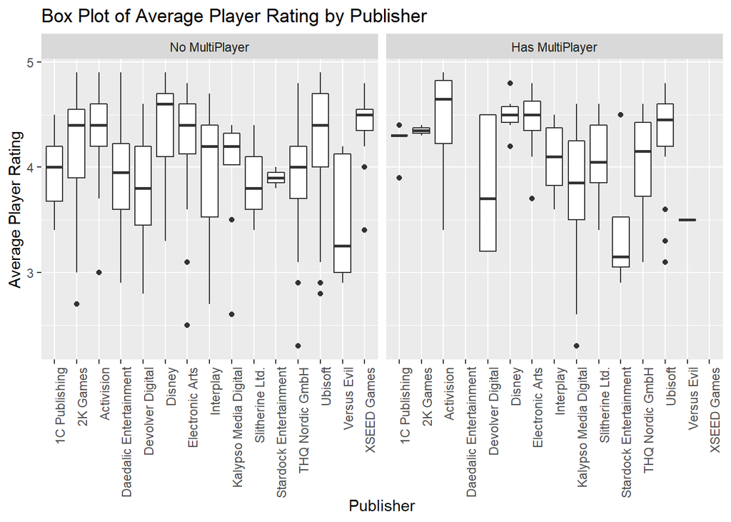

```r
# (ib) box_plots: player rating by publisher, broken down by multiplayer
ggplot(myData, aes(x=publisher, y=player_rating)) +
  geom_boxplot() +
  facet_wrap(multi_player~.,) +
  labs(title="Box Plot of Average Player Rating by Publisher",
       x = "Publisher",
       y = "Average Player Rating") +
   theme(axis.text.x = element_text(angle = 90, hjust = 1))
```

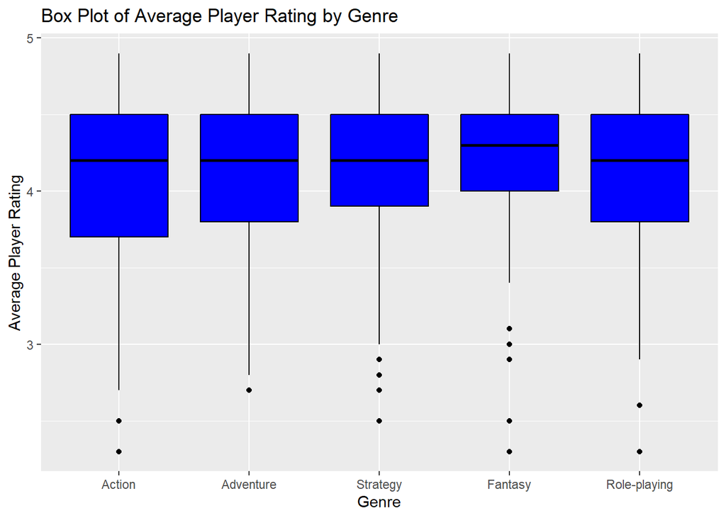

```r
# (iia) box_plots: player rating by genre
# note: observations have dependencies, genres are not independent observations
#       interpret with caution
ratingGenre <- longFromLogicals(myData, topGenres, c("player_rating", "multi_player"), key="genre")
ggplot(ratingGenre, aes(x=as.factor(genre), y=player_rating)) +
  geom_boxplot(color="black", fill="blue") +
  labs(title="Box Plot of Average Player Rating by Genre",
       x="Genre",
       y="Average Player Rating") +
  scale_x_discrete(labels=genreNames)
```

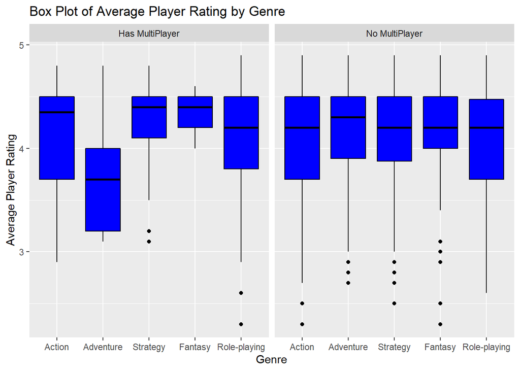

```r
# (iib) box_plots: player rating by genre, broken down by multiplayer
# note: observations have dependencies, genres are not independent observations
#       interpret with caution
ggplot(ratingGenre, aes(x=as.factor(genre), y=player_rating)) +
  geom_boxplot(color="black", fill="blue") +
  facet_wrap(multi_player~.) +
  labs(title="Box Plot of Average Player Rating by Genre",
       x="Genre",
       y="Average Player Rating") +
  scale_x_discrete(labels=genreNames)
```

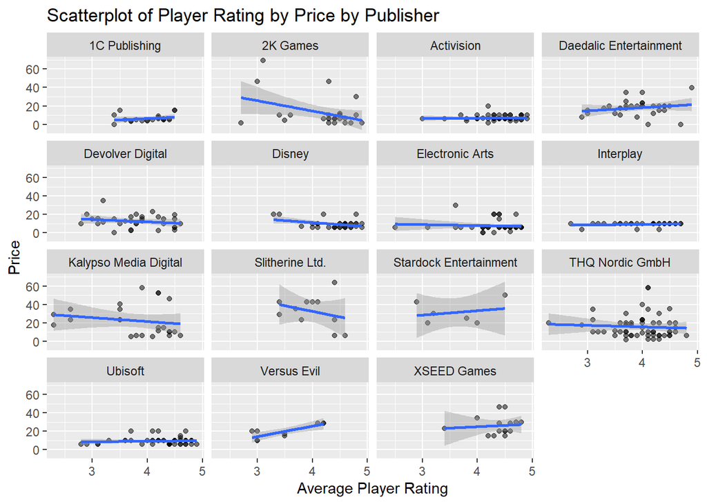

```r
# (iii) scatterplot: of price x player_rating by (color) publisher
ggplot(myData, aes(x=player_rating, y=price)) +
  geom_point(alpha=0.5) +
  geom_smooth(aes(group=publisher), method="lm") +
  facet_wrap(~publisher) +
  labs(title="Scatterplot of Player Rating by Price by Publisher",
       x="Average Player Rating",
       y="Price")
```

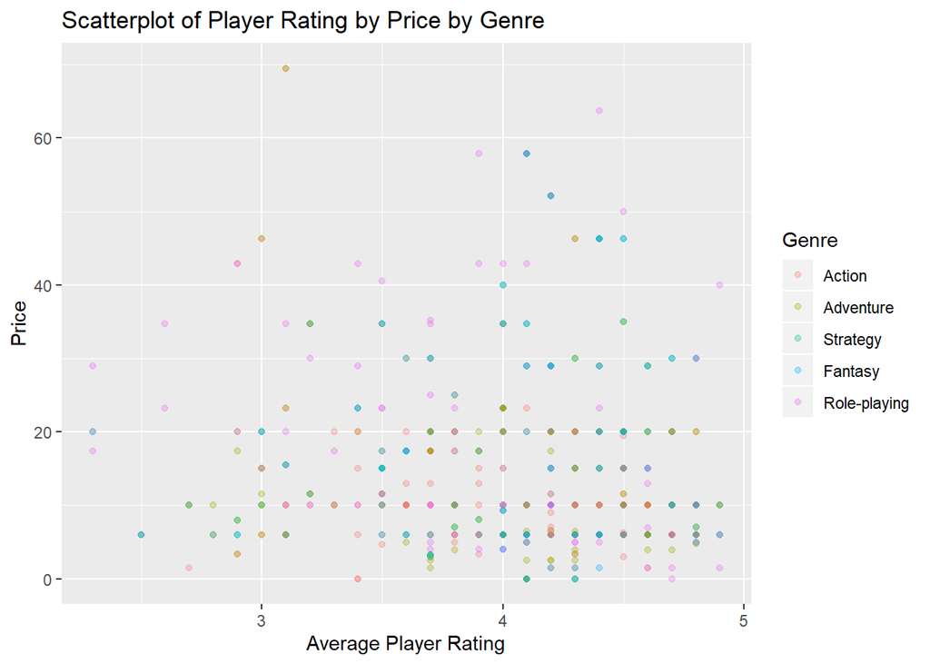

```r
# (iv) scatterplot: of price x player_rating by (panel/color) genre
# note: observations have dependencies, genres are not independent observations
#       interpret with caution
priceRatingGenre <- longFromLogicals(myData, topGenres, c("price", "player_rating"), key="genre")
ggplot(priceRatingGenre, aes(x=player_rating, y=price)) +
  geom_point(aes(color=as.factor(genre)), alpha=0.3) +
  labs(title="Scatterplot of Player Rating by Price by Genre",
       x="Average Player Rating",
       y="Price") +
  scale_color_discrete(name="Genre",
                       labels=genreNames)
```

# Discussion

Overall, the investigation into player rating (a surrogate measure of consumer satisfaction) was able to find at least one strong lead for further investigation. In particular, game publisher seemed to show the strongest variation with player rating and appears to so far be the strongest predictor worth investigating further. Potentially simple underlying explanations (e.g. differences in resources, talent) also make it an attractive starting point for further investigation.

Some ideas for further investigation could be to include video game date of publish, since the quality of video game publishers may change considerably over time. Also, GOG.com sells retro as well as modern games, which may have radically different flavors of consumer reception, so adding date data may help test hypotheses in this area as well. It may also be interesting to dig deeper into the genre and publisher associations with player ratings to see if publishers tend to do well in all genres they produce, or if they tend to perform particularly well in just one or two genres. Exploratory data analysis suggests that some publishers tend to specialize and therefore it is speculated that much of the between-publisher differences in player rating may occur in their areas of specialization. Finally, it is believe that further analysis could begin including all publishers from the original data set in order to provide further insights and possibly help resolve other potential interactions.